# Tema 2

Jose Manuel Valdeolmillos

19 de julio de 2016

## Ejercicio 1

Utiliza los datos iris que corresponden a mediciones (en centímetros) de 4 variables: largo y ancho de los pétalos y sépalos; para 50 flores de 3 especies distintas de plantas Iris setosa, versicolor, y virginica.

#### ¿Cuántos datos (o casos) tenemos para cada especie?

```r
head(iris)
```

```
##   Sepal.Length Sepal.Width Petal.Length Petal.Width Species
## 1          5.1         3.5          1.4         0.2  setosa
## 2          4.9         3.0          1.4         0.2  setosa
## 3          4.7         3.2          1.3         0.2  setosa
## 4          4.6         3.1          1.5         0.2  setosa
## 5          5.0         3.6          1.4         0.2  setosa
## 6          5.4         3.9          1.7         0.4  setosa
```

```r
attach(iris)
```

```r
# tenemos 50 casos de cada especie
table(Species)
```

```
## Species
##     setosa versicolor  virginica
##         50         50         50
```

#### ¿Qué porcentaje representan del total de casos?

```r
# que se corresponde con el 33,3%
round(prop.table(table(Species)), 3) * 100
```

```
## Species
##     setosa versicolor  virginica
##       33.3       33.3       33.3
```

#### Realice los gráficos pertinentes para cada tipo de variable (cualitativa vs. cuantitativa)

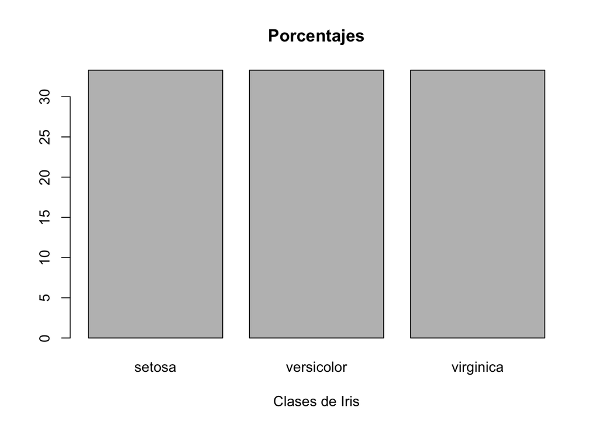

```r
# Gráfico para Species - Variable Cualitativa. Diagrama de barras, por ejemplo:

barplot(round(prop.table(table(Species)), 3) * 100,
        xlab="Clases de Iris",
        main = "Porcentajes")
```

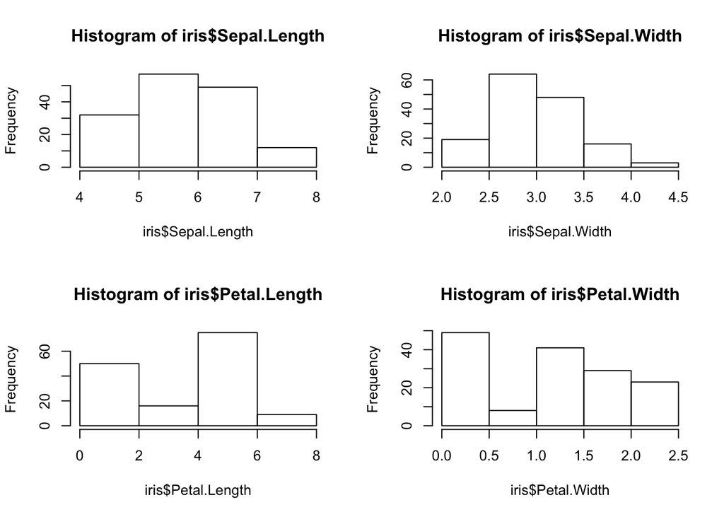

```r
# Gráfico para resto de variables - Variables Cuantitativas Contínuas. Histogramas, por ejemplo:

par(mfrow=c(2,2))
hist(iris$Sepal.Length, breaks = 4)
hist(iris$Sepal.Width, breaks = 4)
hist(iris$Petal.Length, breaks = 4)
hist(iris$Petal.Width, breaks = 4)
```

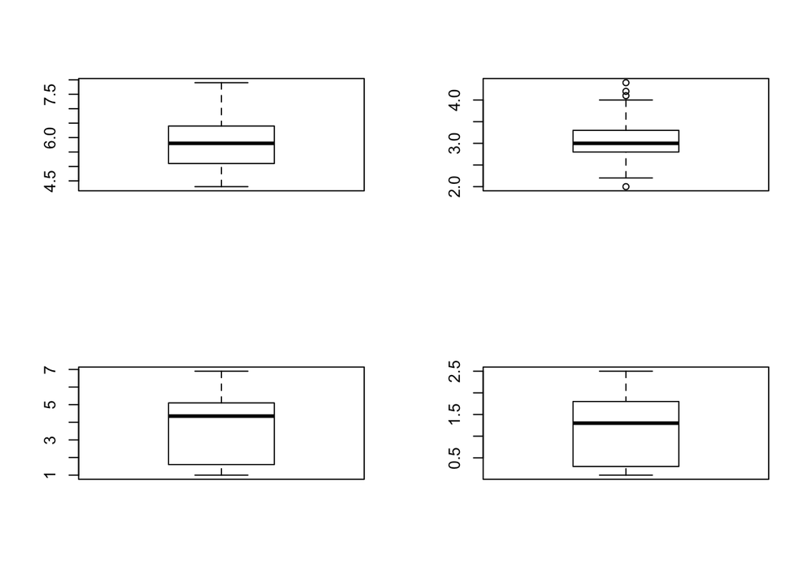

```r
# Gráfico para resto de variables - Variables Cuantitativas Contínuas. Boxplot
# Muestra más información y también outliers:

par(mfrow=c(2,2))
boxplot(iris$Sepal.Length)
boxplot(iris$Sepal.Width)
boxplot(iris$Petal.Length)
boxplot(iris$Petal.Width)
```

#### ¿Cuál es la media clásica y robusta del ancho del sépalo para cada especie?. Realice diagrama de cajas.

```r
# Media clásica por especie:
tapply(iris$Sepal.Width, iris$Species, mean)
```

```
##     setosa versicolor  virginica
##      3.428      2.770      2.974
```

```r
# Media winsorizada por especie:
library(WRS2)
tapply(iris$Sepal.Width, iris$Species, winmean, tr=.2)
```

```
##     setosa versicolor  virginica
##      3.406      2.778      2.958
```

```r
# Media recortada por especie:
tapply(iris$Sepal.Width, iris$Species, mean, trim=.2)
```

```
##     setosa versicolor  virginica
##   3.410000   2.796667   2.963333
```

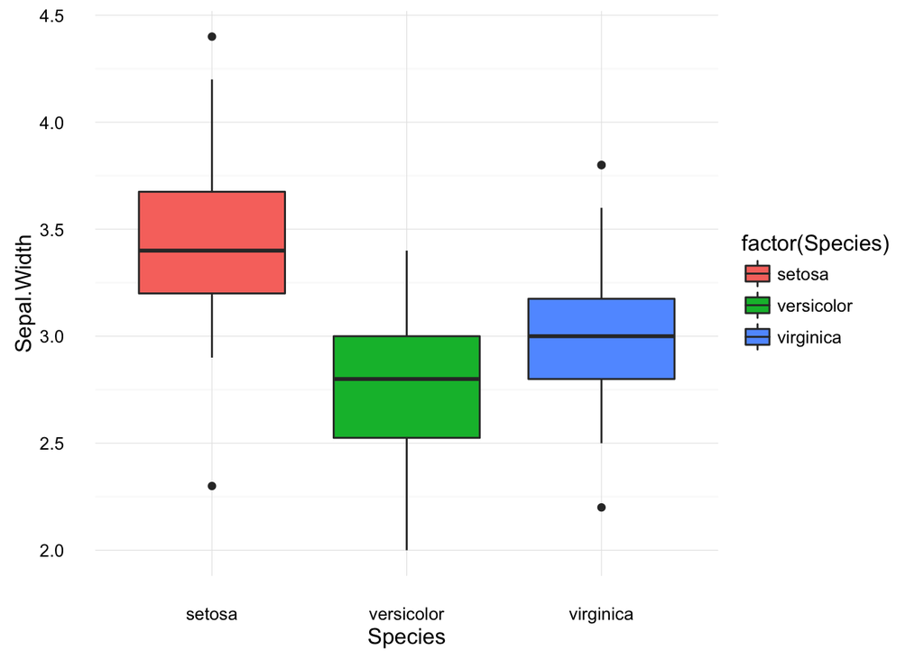

```r
library("ggplot2")
library("gridExtra")
library("plyr")

# Diagrama de cajas para la longitud del sépalo por especie:
ggplot(iris, aes(x=Species, y=Sepal.Width, fill=factor(Species))) + geom_boxplot() + theme_minimal()
```

#### ¿Qué correlaciones existen entre las distintas medidas tomadas a cada planta? Realice un gráfico bidimensional para observarlo.